# Chapter 2: Regression and model validation

- Describe your work and results clearly.
- Assume the reader has an introductory course level understanding of writing and reading R code as well as statistical methods.
- Assume the reader has no previous knowledge of your data or the more advanced methods you are using.

### Analysis: Section 1

I started by checking my working directory

```r
getwd()
```

```
## [1] "C:/Users/OMISTAJA/Documents/IODS-project"
```

Read in the data which includes headers and uses comma as a separator

```r
students2014 <- read.table("C:/Users/OMISTAJA/Documents/IODS-project/data/learning2014.txt", header=TRUE, sep=",")
```

Explored the structure of the data to show that it has 166 obs. of 7 variables

```r
str(students2014)
```

```
## 'data.frame':    166 obs. of  7 variables:
##  $ gender  : Factor w/ 2 levels "F","M": 1 2 1 2 2 1 2 1 2 1 ...
##  $ age     : int  53 55 49 53 49 38 50 37 37 42 ...
##  $ attitude: num  3.7 3.1 2.5 3.5 3.7 3.8 3.5 2.9 3.8 2.1 ...
##  $ deep    : num  3.58 2.92 3.5 3.5 3.67 ...
##  $ stra    : num  3.38 2.75 3.62 3.12 3.62 ...
##  $ surf    : num  2.58 3.17 2.25 2.25 2.83 ...
##  $ points  : int  25 12 24 10 22 21 21 31 24 26 ...
```

Explored the structure of the data using dim(), showing that it has 166 rows and 7 columns

```r
dim(students2014)
```

```
## [1] 166   7
```

**A Brief Description of the Dataset:** This data set is from the international survey of Approaches to Learning. The central measure in this study were questions related to Deep, Surface and Strategic learning answered on a Likert scale. There were 8-12 questions for each category. Combination variables were created from these which were then scaled to the original scales by taking the mean. Data is also included for Age, attitute toward statistics, exam points, and gender. Excluded data: observations with exam points of zero were excluded.

### Analysis: Section 2

A graphical overview of the data using ggplot2 and GGally to make an advanced plot matrix

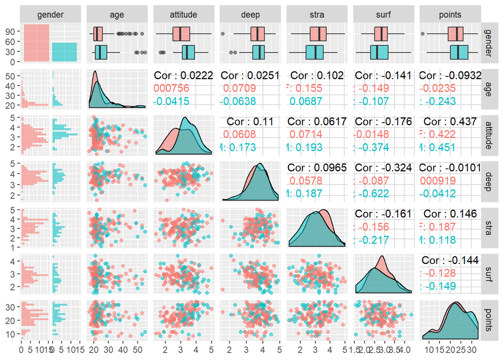

```r
library(ggplot2)
library(GGally)
ggpairs(students2014, mapping = aes(col = gender, alpha = 0.3), lower = list(combo = wrap("facethist", bins = 20)))
```

A summary of the variables in the data

```r
summary(students2014)
```

```
##  gender       age           attitude          deep            stra
##  F:110   Min.   :17.00   Min.   :1.400   Min.   :1.583   Min.   :1.250
##  M: 56   1st Qu.:21.00   1st Qu.:2.600   1st Qu.:3.333   1st Qu.:2.625
##          Median :22.00   Median :3.200   Median :3.667   Median :3.188
##          Mean   :25.51   Mean   :3.143   Mean   :3.680   Mean   :3.121
##          3rd Qu.:27.00   3rd Qu.:3.700   3rd Qu.:4.083   3rd Qu.:3.625
##          Max.   :55.00   Max.   :5.000   Max.   :4.917   Max.   :5.000
##       surf           points
##  Min.   :1.583   Min.   : 7.00
##  1st Qu.:2.417   1st Qu.:19.00
##  Median :2.833   Median :23.00
##  Mean   :2.787   Mean   :22.72
##  3rd Qu.:3.167   3rd Qu.:27.75
##  Max.   :4.333   Max.   :33.00
```

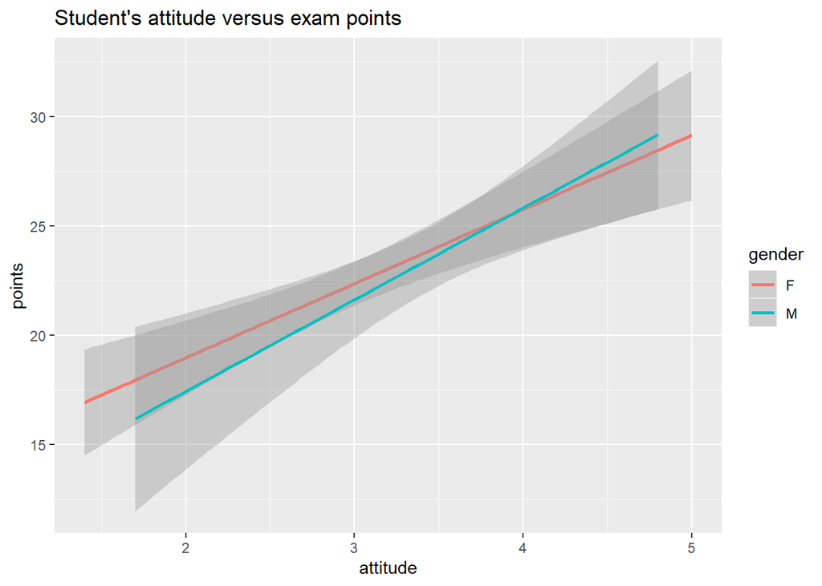

```r
gender_comparison <- ggplot(students2014, aes(x = attitude, y = points, col = gender, labs(title="Student's attitude versus exam points")))
gender_comparison + ggtitle("Student's attitude versus exam points") + geom_smooth(method = "lm")
```

### Analysis: Section 3 & 4

Three explanatory variables (attitude, strategic learning, surface learning) fitted to a regression model with exam points as the target (dependent) variable:

```r
summary(lm(points ~ attitude + stra + surf, data = students2014))
```

```
##
## Call:
## lm(formula = points ~ attitude + stra + surf, data = students2014)
##
## Residuals:
##      Min       1Q   Median       3Q      Max
## -17.1550  -3.4346   0.5156   3.6401  10.8952
##
## Coefficients:
##             Estimate Std. Error t value Pr(>|t|)
## (Intercept)  11.0171     3.6837   2.991  0.00322 **
## attitude      3.3952     0.5741   5.913 1.93e-08 ***
## stra          0.8531     0.5416   1.575  0.11716
## surf         -0.5861     0.8014  -0.731  0.46563
## ---
## Signif. codes:  0 '***' 0.001 '**' 0.01 '*' 0.05 '.' 0.1 ' ' 1
##
## Residual standard error: 5.296 on 162 degrees of freedom
## Multiple R-squared:  0.2074, Adjusted R-squared:  0.1927
## F-statistic: 14.13 on 3 and 162 DF,  p-value: 3.156e-08
```

Interpretation of the results: Attitude is the only statistically significant predictor of exam points with a t-test p value, Pr(>|t|), less than 0.001. The better people’s attitude towards learning was the better they tended to do in the exam.

```r
final_model <- lm(points ~ attitude, data = students2014)
summary("final_model")
```

```
##    Length     Class      Mode
##         1 character character
```

### Analysis: Section 5

Diagnostic plots: Residuals vs Fitted values, Normal QQ-plot and Residuals vs Leverage.

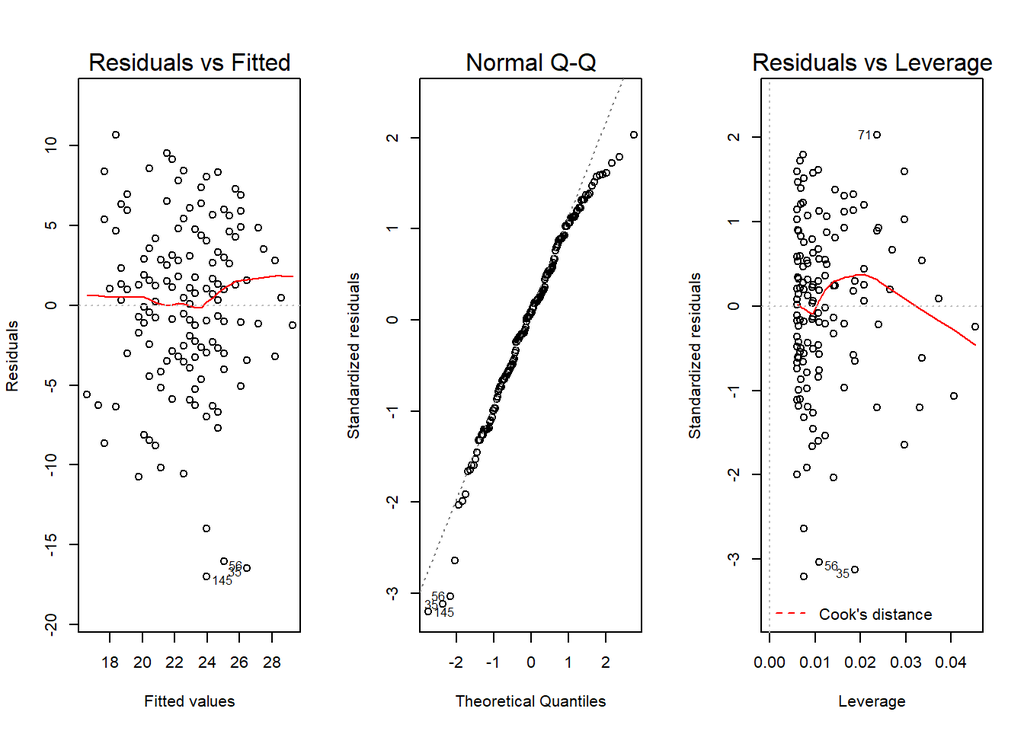

```r
par(mfrow = c(1,3))
plot(final_model, which = c(1,2,5))
```

The assumptions of a linear regression model are: * Errors have constant variance σ^2 * Errors normally distributed * Errors not correlated * The size of a given error does not depend on the explanatory variables

The variance of the errors are reasonable constant, this is shown by the values in the Residuals vs Fitted values plot being randomly scattered. The errors are normally distributed, this is shown by most of the values staying along the regression line in the QQ plot. No one value should have a leverage and while the Residuals vs Leverage plot shows outliers with higher leverage the x-axis is very short so the graphic makes it seem like a bigger problem than it is.